# How to Collect Digital Trace Data: APIs

Chris Bail, Duke University  
SICSS, Day 2

### What is an API?

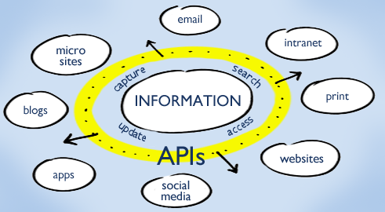

### The API Explosion

[figure not shown]

### Let's Look at an API

**Please visit this [link](https://developers.facebook.com/tools/explorer)**

https://developers.facebook.com/tools/explorer

### The Facebook Graph API Explorer

[figure not shown]

### Many R Packages Interface with APIs

```r
install.packages("twitteR")
```

And load it:

```r
library(twitteR)
```

### ..But first you need "credentials"

### ..You need to register as a Developer

**Go here:**

apps.twitter.com

### Sign Up Here

[figure not shown]

### Create a New App

[figure not shown]

### Name it Whatever you Want

[figure not shown]

### Get your "Credentials"

[figure not shown]

### Get your Keys and Tokens!

[figure not shown]

### Passing Credentials to R

**The Twitter package requires that you pass your “credentials” before you make any data requests. After you run the code below, choose 'Using direct authentication.'**

```r
setup_twitter_oauth(consumer_key="TEXTOFYOURKEYHERE",
                    consumer_secret="TEXTOFYOURSECRETHERE",
                    access_token="TEXTOFACCESSTOKENHERE",
                    access_secret="TEXTOFACCESSSECRETHERE")
```

```
[1] "Using direct authentication"
```

### Now Let's Try it out

```r
user <- getUser("chris_bail")
```

### Let's Grab my Tweets

```r
tweets<-userTimeline(user)
tweets
```

```
[[1]]
[1] "chris_bail: @c_schwemmer @msalganik No problem- sorry for the hassle (this is our first time livestreaming this event)"

[[2]]
[1] "chris_bail: @anna_fil @calebthompson @msalganik Yes we are hoping to archive all talks but not yet sure when they will be posted- hopefully very soon."

[[3]]
[1] "chris_bail: @c_schwemmer @msalganik Also please try another browser- appears to work better on Firefox/Safari than Chrome."

[[4]]
[1] "chris_bail: @c_schwemmer @msalganik Looks like you might just need to refresh your browser after the coffee breaks"

[[5]]
[1] "chris_bail: @c_schwemmer @msalganik Working on it sorry"

[[6]]
[1] "chris_bail: All slides and code for the Summer Institute in Computational Social Science #SICSS2017 are available here: https://t.co/d0Sm6IdR9t"

[[7]]
[1] "chris_bail: Watch @msalganik talk about ethics live at #SCISS2017: https://t.co/RE64z1urMG"

[[8]]
[1] "chris_bail: audio for livestream of #SICSS at Princeton should be working now: https://t.co/9oA7ImZWDt"

[[9]]
[1] "chris_bail: @jeffswin Looks like it's going to take ~10 minutes to fix this- sorry! Eventually this lecture will be archived an… https://t.co/4gFTrCmx46"

[[10]]
[1] "chris_bail: @jeffswin Matt is arguing that comp soc science needs a capacious definition given that the field is inherently interdisciplinary."

[[11]]
[1] "chris_bail: @jeffswin Sorry- just talked to the sound guy should be online soon."

[[12]]
[1] "chris_bail: Watch @msalganik on \"what is computational social science\" on the #SICSS2017 livestream at 9:10 this morning: https://t.co/VgRxRqdDfb"

[[13]]
[1] "chris_bail: livestream for #SICSS will begin in ~10 minutes here: https://t.co/VgRxRqdDfb"

[[14]]
[1] "chris_bail: Livestream of Summer Institute in Computational Social Science at Princeton begins tomorrow at 9AM! https://t.co/RJvGMKYYJs"

[[15]]
[1] "chris_bail: @JessicaScott09 @mbfhunzaker We are hoping to put them on YouTube but there may be some permissions issues."

[[16]]
[1] "chris_bail: 2/2 Remember all lectures assume basic coding knowledge, which you can get from these DataCamp courses: https://t.co/d0Sm6IdR9t"

[[17]]
[1] "chris_bail: 1/2 Summer Institute in Comp. Social Science begins June 19th at 9am! Watch the live stream here: https://t.co/IlPdj0JZlT"
```

### Who do I follow?

```r
friends<-user$getFriends()
```

### Let's view it

```r
friends
```

```
$`157466475`
[1] "mollyeroberts"

$`3639333494`
[1] "mollyllewis"

$`104427626`
[1] "anna_fil"

$`1606636968`
[1] "dustintingley"

$`574924256`
[1] "mbfhunzaker"

$`15425914`
[1] "jboy"

$`389562551`
[1] "annliffey"

$`1075005146`
[1] "Hegghammer"

$`300845635`
[1] "hoffman_bruce"

$`151935833`
[1] "JessicaEStern"

$`1323603420`
[1] "MiaMBloom"

$`47101500`
[1] "intelwire"

$`709782739`
[1] "Drjohnhorgan"

$`997629601`
```

[output cut: 958 more lines]

```

$`351906466`
[1] "vaiseys"

$`7966972`
[1] "jeremyfreese"

$`104071865`
[1] "WITWhat"

$`442480428`
[1] "omar_lizardo"

$`84653850`
[1] "BrendanNyhan"
```

### Who Follows Me?

```r
followers<-user$getFollowers()
followers
```

```
$`1023575275`
[1] "GarrettPace1"

$`19854920`
[1] "computermacgyve"

$`104427626`
[1] "anna_fil"

$`3639333494`
[1] "mollyllewis"

$`1599902202`
[1] "MarlonMasine"

$`876384015095410688`
[1] "Sandra18382574"

$`871437799152533504`
[1] "quasi_maybe"

$`14525356`
[1] "nuruddinAB"

$`1902747967`
[1] "jdylan901"

$`2315046061`
[1] "nadiakhanitp"

$`623115924`
[1] "lc_1979"

$`389562551`
[1] "annliffey"

$`629804395`
[1] "timetowakeup00"

$`75118960`
```

[output cut: 4546 more lines]

```

$`551230758`
[1] "SociologistRay"

$`381592902`
[1] "GabrielRossman"

$`38047391`
[1] "familyunequal"

$`29193463`
[1] "shamuskhan"

$`84653850`
[1] "BrendanNyhan"
```

### What are My Favorite Tweets?

```r
favorites<-favorites(user)
favorites
```

```
[[1]]
[1] "alliecmorgan: Excited to get started! Here's what I'll be up to for the next two weeks, in case you wanna follow along: https://t.co/WTX7g3hzyC"

[[2]]
[1] "omar_lizardo: Looks like Neil's beard is entering mid-career Peter Blau stage https://t.co/E9Ypnlu2fH"

[[3]]
[1] "jeremyfreese: Spotted in Palo Alto. I know nothing about the owner except that s/he has defeated us all at life. https://t.co/hJ5eWyWb2d"

[[4]]
[1] "msalganik: Announcing #FragileFamiliesChallenge getting started workshop Fri 6/23 in Princeton and everywhere via livestream:… https://t.co/JTJVUgrEyb"

[[5]]
[1] "thomasrdavidson: I just published “Social media and the 2017 general election” https://t.co/MJy8SbHl5L"

[[6]]
[1] "sgadarian: Not sure it's a big deal that @SenKamalaHarris gets interrupted more than her male colleagues during committee meetings? Here's some reading"

[[7]]
[1] "iowahawkblog: House of Cards is popular in DC because they prefer being depicted as homicidal evil geniuses than overpromoted student council morons"

[[8]]
[1] "intelwire: In other words, he's definitely going to do it https://t.co/Tj7FQlhNgf"

[[9]]
[1] "intelwire: @Drjohnhorgan OWWWWW MY BRAIN"

[[10]]
[1] "dfreelon: TFW someone cites you but gets a key stat wrong https://t.co/FezohbeIUx"

[[11]]
[1] "Nate_Cohn: The Merkel/Macron/Trudeau group text thread must be pretty great"

[[12]]
[1] "JessicaCalarco: A very loudly ticking biological clock (baby #2 is due in 9 days) is great for productivity. Grant revisions? Check. Book revisions? Check."

[[13]]
[1] "RuthBraunstein: Excited to announce that my book, Prophets &amp; Patriots: Faith in Democracy Across the Political Divide, is out! https://t.co/NW1OmyUZHE"

[[14]]
[1] "msalganik: Database of all papers using the Fragile Families data: https://t.co/6RTEHlGjX7 How could this be used for #FragileFamiliesChallenge?"

[[15]]
[1] "kreissdaniel: McCain doesn't seem okay."

[[16]]
[1] "Chanders: We suck."

[[17]]
[1] "Chanders: Cool conference in Oslo, featuring @chris_bail, @couldrynick @annliffey and others (CFP) https://t.co/tgvk90YtVh"

[[18]]
[1] "jboy: The call is out for Social Media &amp; Social Order, an int'l conference feat. @chris_bail, @couldrynick &amp; @annliffey: https://t.co/0SHDMyQpsz"

[[19]]
[1] "hasavrat: @SpeakerRyan Last fun factoid! Joe Strummer of The Clash was born in Ankara. (His Dad was a British diplomat at the… https://t.co/eWzLKP3ESA"

[[20]]
[1] "AlbertsonB2: I've told lots of classes that it's relatively easy to pass legislation when one party controls Congress and the White House. I'm sorry."
```

### And Move it to Data Frame...

```r
friendsdata <- twListToDF(friends)
followersdata <- twListToDF(followers)
```

### Rate Limiting

Even though APIs are far more convenient to use than screenscraping, they also prevent you from collecting too much data within too short a time frame (for a variety of reasons).

### Find the Rate Limits

```r
getCurRateLimitInfo()
```

### ...And if we want to look:

```r
head(twitter_data)
```

[output not shown]

### Let's use the data we scraped...

**Now let's take the data we scraped earlier and create a network of celebrities. First, we create a blank data frame to store data we get from the Twitter API:**

```r
twitter_network_data<-as.data.frame(NULL)
```

**Figure out how many rows we have to scrape:**

```r
z<-nrow(twitter_data)
```

### Our Loop

```r
for(i in 1:z){
  user <- getUser(twitter_data$twitter_handles[i])
  people_user_follows <- user$getFriends()
  people_user_follows<-twListToDF(people_user_follows)
  people_user_follows$name_of_user<-twitter_data$twitter_handles[i]
  twitter_network_data<-rbind(twitter_network_data, people_user_follows)
  Sys.sleep(60)
  print(i)
}
```

### But this would take too long

**I've already scraped the data and saved it in our Dropbox:**

```r
load("Twitter Network Data.Rdata")
```

### There are R packages for other APIs

Here are but a few: `RgoogleMaps`, `Rfacebook`, `rOpenSci`(this one combines many different APIs e.g. the Internet Archive), `WDI`,`rOpenGov`,`rtimes`

Many more are available but not yet on CRAN (install from github or using devtools)

### There are also APIs that do Analysis for You!

**For example, visualization (`plotly`)**

### Working with APIs from "scratch"

**What if you want to collect data from an API that does not have an R package?**

### Let's pretend there is no R package for Google Maps

**We can look for patterns in API queries in the documentation:**

https://maps.googleapis.com/maps/api/geocode/json?address=Durham,NorthCarolina&sensor=false

**In this case, address goes between the first** `=` **and the** `&`

### Let's write a function

```r
findGPS <- function(address) {
 beginning <- "http://maps.google.com/maps/api/geocode/json?"
 paster <- paste0(beginning,"address=", address, "&sensor=false")
 return(URLencode(paster))
}
```

### Let's try our function

```r
findGPS("Durham, North Carolina")
```

```
[1] "http://maps.google.com/maps/api/geocode/json?address=Durham,%20North%20Carolina&sensor=false"
```

### Sweet sweet JSON!

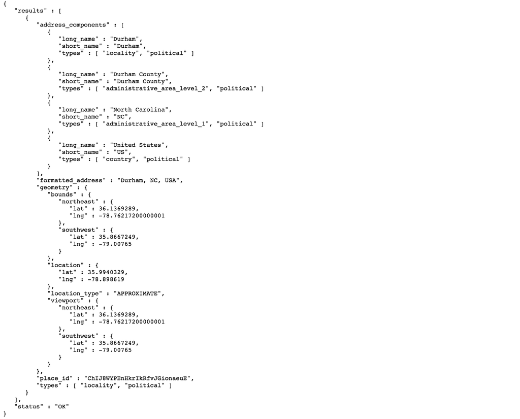

### Now we need to get the JSON

**We need the RJSONIO package- or alternatively the more recent jsonlite package**:

```r
library(RJSONIO)
page<-findGPS("Durham, North Carolina")
gpscoordinates <- fromJSON(page)
latitude <- gpscoordinates$results[[1]]$geometry$location["lat"]
longitude <- gpscoordinates$results[[1]]$geometry$location["lng"]
gps<-c(latitude, longitude)
gps
```

[output not shown]

### One Final Tip: Unix Time/Dates

At some point you will probably need to work with time stamps- particularly if you collect data from a social media site

### One Final Tip: Unix Time/Dates

Unix time is seconds that have elapsed since 1/1/1970. Handy because it is a consistent format that can be grouped easily, but most time stamps will look like dates. To handle these use `strptime`

```r
x <- strptime(c("2006-01-08 10:07:52", "2006-08-07 19:33:02"),"%Y-%m-%d %H:%M:%S", tz = "EST5EDT")
x
```

```
[1] "2006-01-08 10:07:52 EST" "2006-08-07 19:33:02 EDT"
```

# **QUESTIONS?**

### Summary

Screen-scraping has become “old-school.” It is probably only useful if you want to scrape data from older web pages, or decidedly public pages such as Wikipedia

### Summary

APIs are much more promising, but they have significant limitations as well (e.g. data owneserhip issues, rate limiting, data are prepared for app-construction/advertising instead of social science)

### Remember:

Read the terms of service.

### APIs of Interest to Social Scientists

[This](https://docs.google.com/spreadsheets/d/1ZEr3okdlb0zctmX0MZKo-gZKPsq5WGn1nJOxPV7al-Q/edit?usp=sharing) is a crowd-sourced list of APIs that may be of interest to social scientists which I curate:

# **QUESTIONS?**

# **AFTER LUNCH: BUILDING APPS FOR SOCIAL SCIENCE RESEARCH**